# HDT3-Arboles de decision

##### Dado que el valor de la silueta disminuye en los clusteres, la silueta no mejora.

4. Dependiendo del análisis exploratorio elaborado cree una variable respuesta que le permita clasificar las casas en Económicas, Intermedias o Caras. Los límites de estas clases deben tener un fundamento en la distribución de los datos de precios, y estar bien explicados.

por ende, determinamos con una variable nueva en nuestra base de datos llamada “clasification” para poder etiquetar y ordenar cada una de las casas segun perteneza a su rango de precio.

```r
datos$clasification <- ifelse(datos$SalePrice > 290000, "Caras", ifelse(datos$SalePrice>170000, "Intemedia", "Economicas"))
table(datos$clasification)
```

```
##
##      Caras Economicas  Intemedia
##        121        792        547
```

5. Divida el set de datos preprocesados en dos conjuntos: Entrenamiento y prueba. Describa el criterio que usó para crear los conjuntos: número de filas de cada uno, estratificado o no, balanceado o no, etc. Si le proveen un conjunto de datos de prueba y tiene suficientes datos, tómelo como de validación, pero haga sus propios conjuntos de prueba.

La division de los sets se ha decidido por porcentajes de 70% para entrenamiento y 30% para prueba.

```r
library(dplyr)
set_entrenamiento <- sample_frac(datos, .7)
set_prueba <-setdiff(datos, set_entrenamiento)


drop <- c("LotFrontage", "Alley", "MasVnrType", "MasVnrArea", "BsmtQual", "BsmtCond", "BsmtExposure", "BsmtFinType1", "BsmtFinType2", "Electrical", "FireplaceQu", "GarageType", "GarageYrBlt", "GarageFinish", "GarageQual", "GarageCond", "PoolQC", "Fence", "MiscFeature")
set_entrenamiento <- set_entrenamiento[, !(names(set_entrenamiento) %in% drop)]
set_prueba <- set_prueba[, !(names(set_prueba) %in% drop)]
```

6. Elabore el árbol de clasificación utilizando el conjunto de entrenamiento y la variable respuesta que creó en el punto 4. Explique los resultados a los que llega. Muestre el modelo gráficamente. El experimento debe ser reproducible por lo que debe fijar que los conjuntos de entrenamiento y prueba sean los mismos siempre que se ejecute el código.

```r
library(rpart)
arbol_1 <- rpart(formula = clasification ~ ., data = set_entrenamiento)
arbol_1
```

```
## n= 1022
##
## node), split, n, loss, yval, (yprob)
##       * denotes terminal node
##
## 1) root 1022 473 Economicas (0.08708415 0.53718200 0.37573386)
##   2) SalePrice< 170500 549   0 Economicas (0.00000000 1.00000000 0.00000000) *
##   3) SalePrice>=170500 473  89 Intemedia (0.18816068 0.00000000 0.81183932)
##     6) SalePrice>=291538.5 89   0 Caras (1.00000000 0.00000000 0.00000000) *
##     7) SalePrice< 291538.5 384   0 Intemedia (0.00000000 0.00000000 1.00000000) *
```

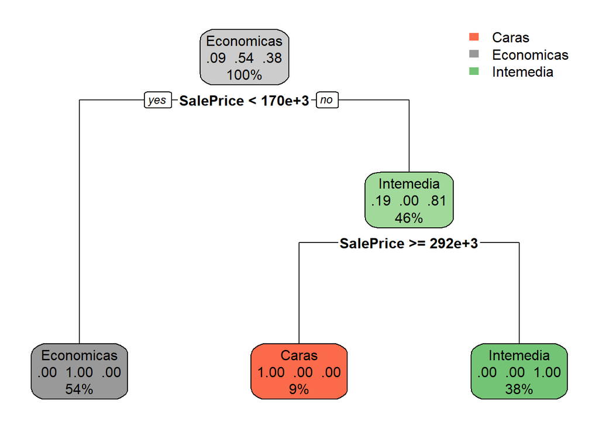

```r
library(rpart.plot)

rpart.plot(arbol_1)
```

Dado que el arbol de decision se basa en designar la variable creada en el inciso cuatro la cual indica la categoria de precio de las casa, se le ha indicado al modelo que debe trabajar en base a las demas variables. Como se puede observar el arbol utiliza el precio de venta para determinarlo.